# Homework1

Author

Derek Walker

## Question 1

```r
library(data.table)
library(dplyr)
library(ggplot2)
library(stats)
dta2002 <- as.data.table(read.table(file='/Users/gazallab/Downloads/ad_viz_plotval_data-2.csv', header=T, sep=","))


dta2022 <- as.data.table(read.table(file='/Users/gazallab/Downloads/ad_viz_plotval_data.csv',header=T, sep=','))


head(dta2002)
```

```
         Date Source  Site.ID POC Daily.Mean.PM2.5.Concentration    UNITS
1: 01/05/2002    AQS 60010007   1                           25.1 ug/m3 LC
2: 01/06/2002    AQS 60010007   1                           31.6 ug/m3 LC
3: 01/08/2002    AQS 60010007   1                           21.4 ug/m3 LC
4: 01/11/2002    AQS 60010007   1                           25.9 ug/m3 LC
5: 01/14/2002    AQS 60010007   1                           34.5 ug/m3 LC
6: 01/17/2002    AQS 60010007   1                           41.0 ug/m3 LC
   DAILY_AQI_VALUE Site.Name DAILY_OBS_COUNT PERCENT_COMPLETE
1:              78 Livermore               1              100
2:              92 Livermore               1              100
3:              71 Livermore               1              100
4:              80 Livermore               1              100
5:              98 Livermore               1              100
6:             115 Livermore               1              100
   AQS_PARAMETER_CODE       AQS_PARAMETER_DESC CBSA_CODE
```

[output cut: 20 more lines]

```r
tail(dta2002)
```

```
         Date Source  Site.ID POC Daily.Mean.PM2.5.Concentration    UNITS
1: 12/10/2002    AQS 61131003   1                             15 ug/m3 LC
2: 12/13/2002    AQS 61131003   1                             15 ug/m3 LC
3: 12/22/2002    AQS 61131003   1                              1 ug/m3 LC
4: 12/25/2002    AQS 61131003   1                             23 ug/m3 LC
5: 12/28/2002    AQS 61131003   1                              5 ug/m3 LC
6: 12/31/2002    AQS 61131003   1                              6 ug/m3 LC
   DAILY_AQI_VALUE            Site.Name DAILY_OBS_COUNT PERCENT_COMPLETE
1:              57 Woodland-Gibson Road               1              100
2:              57 Woodland-Gibson Road               1              100
3:               4 Woodland-Gibson Road               1              100
4:              74 Woodland-Gibson Road               1              100
5:              21 Woodland-Gibson Road               1              100
6:              25 Woodland-Gibson Road               1              100
   AQS_PARAMETER_CODE       AQS_PARAMETER_DESC CBSA_CODE
```

[output cut: 20 more lines]

```r
head(dta2022)
```

```
         Date Source  Site.ID POC Daily.Mean.PM2.5.Concentration    UNITS
1: 01/01/2022    AQS 60010007   3                           12.7 ug/m3 LC
2: 01/02/2022    AQS 60010007   3                           13.9 ug/m3 LC
3: 01/03/2022    AQS 60010007   3                            7.1 ug/m3 LC
4: 01/04/2022    AQS 60010007   3                            3.7 ug/m3 LC
5: 01/05/2022    AQS 60010007   3                            4.2 ug/m3 LC
6: 01/06/2022    AQS 60010007   3                            3.8 ug/m3 LC
   DAILY_AQI_VALUE Site.Name DAILY_OBS_COUNT PERCENT_COMPLETE
1:              52 Livermore               1              100
2:              55 Livermore               1              100
3:              30 Livermore               1              100
4:              15 Livermore               1              100
5:              18 Livermore               1              100
6:              16 Livermore               1              100
   AQS_PARAMETER_CODE       AQS_PARAMETER_DESC CBSA_CODE
```

[output cut: 20 more lines]

```r
tail(dta2022)
```

```
         Date Source  Site.ID POC Daily.Mean.PM2.5.Concentration    UNITS
1: 12/01/2022    AQS 61131003   1                            3.4 ug/m3 LC
2: 12/07/2022    AQS 61131003   1                            3.8 ug/m3 LC
3: 12/13/2022    AQS 61131003   1                            6.0 ug/m3 LC
4: 12/19/2022    AQS 61131003   1                           34.8 ug/m3 LC
5: 12/25/2022    AQS 61131003   1                           23.2 ug/m3 LC
6: 12/31/2022    AQS 61131003   1                            1.0 ug/m3 LC
   DAILY_AQI_VALUE            Site.Name DAILY_OBS_COUNT PERCENT_COMPLETE
1:              14 Woodland-Gibson Road               1              100
2:              16 Woodland-Gibson Road               1              100
3:              25 Woodland-Gibson Road               1              100
4:              99 Woodland-Gibson Road               1              100
5:              74 Woodland-Gibson Road               1              100
6:               4 Woodland-Gibson Road               1              100
   AQS_PARAMETER_CODE       AQS_PARAMETER_DESC CBSA_CODE
```

[output cut: 20 more lines]

```r
dim(dta2002)
```

```
[1] 15976    20
```

```r
dim(dta2022)
```

```
[1] 57761    20
```

```r
str(dta2002)
```

```
Classes 'data.table' and 'data.frame':  15976 obs. of  20 variables:
 $ Date                          : chr  "01/05/2002" "01/06/2002" "01/08/2002" "01/11/2002" ...
 $ Source                        : chr  "AQS" "AQS" "AQS" "AQS" ...
 $ Site.ID                       : int  60010007 60010007 60010007 60010007 60010007 60010007 60010007 60010007 60010007 60010007 ...
 $ POC                           : int  1 1 1 1 1 1 1 1 1 1 ...
 $ Daily.Mean.PM2.5.Concentration: num  25.1 31.6 21.4 25.9 34.5 41 29.3 15 18.8 37.9 ...
 $ UNITS                         : chr  "ug/m3 LC" "ug/m3 LC" "ug/m3 LC" "ug/m3 LC" ...
 $ DAILY_AQI_VALUE               : int  78 92 71 80 98 115 87 57 65 107 ...
 $ Site.Name                     : chr  "Livermore" "Livermore" "Livermore" "Livermore" ...
 $ DAILY_OBS_COUNT               : int  1 1 1 1 1 1 1 1 1 1 ...
 $ PERCENT_COMPLETE              : num  100 100 100 100 100 100 100 100 100 100 ...
 $ AQS_PARAMETER_CODE            : int  88101 88101 88101 88101 88101 88101 88101 88101 88101 88101 ...
 $ AQS_PARAMETER_DESC            : chr  "PM2.5 - Local Conditions" "PM2.5 - Local Conditions" "PM2.5 - Local Conditions" "PM2.5 - Local Conditions" ...
 $ CBSA_CODE                     : int  41860 41860 41860 41860 41860 41860 41860 41860 41860 41860 ...
 $ CBSA_NAME                     : chr  "San Francisco-Oakland-Hayward, CA" "San Francisco-Oakland-Hayward, CA" "San Francisco-Oakland-Hayward, CA" "San Francisco-Oakland-Hayward, CA" ...
 $ STATE_CODE                    : int  6 6 6 6 6 6 6 6 6 6 ...
 $ STATE                         : chr  "California" "California" "California" "California" ...
 $ COUNTY_CODE                   : int  1 1 1 1 1 1 1 1 1 1 ...
 $ COUNTY                        : chr  "Alameda" "Alameda" "Alameda" "Alameda" ...
 $ SITE_LATITUDE                 : num  37.7 37.7 37.7 37.7 37.7 ...
 $ SITE_LONGITUDE                : num  -122 -122 -122 -122 -122 ...
 - attr(*, ".internal.selfref")=<externalptr>
```

```r
str(dta2022)
```

```
Classes 'data.table' and 'data.frame':  57761 obs. of  20 variables:
 $ Date                          : chr  "01/01/2022" "01/02/2022" "01/03/2022" "01/04/2022" ...
 $ Source                        : chr  "AQS" "AQS" "AQS" "AQS" ...
 $ Site.ID                       : int  60010007 60010007 60010007 60010007 60010007 60010007 60010007 60010007 60010007 60010007 ...
 $ POC                           : int  3 3 3 3 3 3 3 3 3 3 ...
 $ Daily.Mean.PM2.5.Concentration: num  12.7 13.9 7.1 3.7 4.2 3.8 2.3 6.9 13.6 11.2 ...
 $ UNITS                         : chr  "ug/m3 LC" "ug/m3 LC" "ug/m3 LC" "ug/m3 LC" ...
 $ DAILY_AQI_VALUE               : int  52 55 30 15 18 16 10 29 54 47 ...
 $ Site.Name                     : chr  "Livermore" "Livermore" "Livermore" "Livermore" ...
 $ DAILY_OBS_COUNT               : int  1 1 1 1 1 1 1 1 1 1 ...
 $ PERCENT_COMPLETE              : num  100 100 100 100 100 100 100 100 100 100 ...
 $ AQS_PARAMETER_CODE            : int  88101 88101 88101 88101 88101 88101 88101 88101 88101 88101 ...
 $ AQS_PARAMETER_DESC            : chr  "PM2.5 - Local Conditions" "PM2.5 - Local Conditions" "PM2.5 - Local Conditions" "PM2.5 - Local Conditions" ...
 $ CBSA_CODE                     : int  41860 41860 41860 41860 41860 41860 41860 41860 41860 41860 ...
 $ CBSA_NAME                     : chr  "San Francisco-Oakland-Hayward, CA" "San Francisco-Oakland-Hayward, CA" "San Francisco-Oakland-Hayward, CA" "San Francisco-Oakland-Hayward, CA" ...
 $ STATE_CODE                    : int  6 6 6 6 6 6 6 6 6 6 ...
 $ STATE                         : chr  "California" "California" "California" "California" ...
 $ COUNTY_CODE                   : int  1 1 1 1 1 1 1 1 1 1 ...
 $ COUNTY                        : chr  "Alameda" "Alameda" "Alameda" "Alameda" ...
 $ SITE_LATITUDE                 : num  37.7 37.7 37.7 37.7 37.7 ...
 $ SITE_LONGITUDE                : num  -122 -122 -122 -122 -122 ...
 - attr(*, ".internal.selfref")=<externalptr>
```

```r
mean(is.na(dta2022))
```

```
[1] 0.004121293
```

```r
mean(which(is.na(dta2022)))
```

```
[1] 719906.3
```

```r
names(which(colSums(is.na(dta2002))>0))
```

```
[1] "CBSA_CODE"
```

```r
names(which(colSums(is.na(dta2022))>0))
```

```
[1] "CBSA_CODE"
```

```r
summary(dta2002$CBSA_CODE)
```

```
   Min. 1st Qu.  Median    Mean 3rd Qu.    Max.    NA's
  12540   23420   40140   33270   41740   49700     929
```

```r
summary(dta2022$CBSA_CODE)
```

```
   Min. 1st Qu.  Median    Mean 3rd Qu.    Max.    NA's
  12540   31080   40140   35445   41860   49700    4761
```

```r
summary(dta2002$Daily.Mean.PM2.5.Concentration)
```

```
   Min. 1st Qu.  Median    Mean 3rd Qu.    Max.
   0.00    7.00   12.00   16.12   20.50  104.30
```

```r
summary(dta2022$Daily.Mean.PM2.5.Concentration)
```

```
   Min. 1st Qu.  Median    Mean 3rd Qu.    Max.
 -2.200   4.200   7.000   8.564  10.900 302.500
```

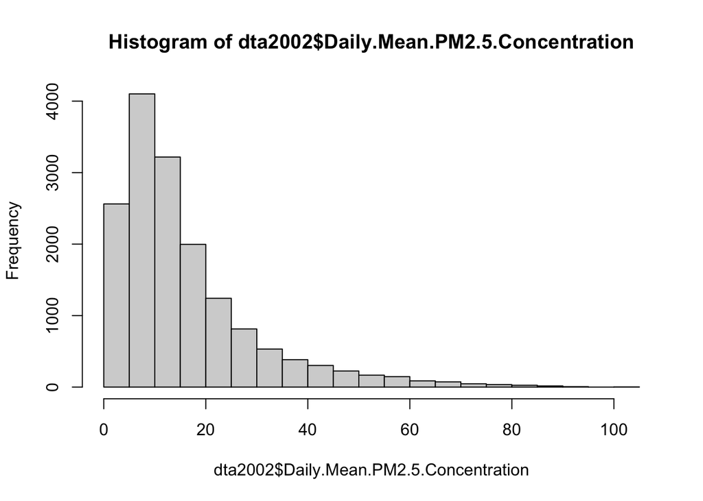

```r
hist(dta2002$Daily.Mean.PM2.5.Concentration)
```

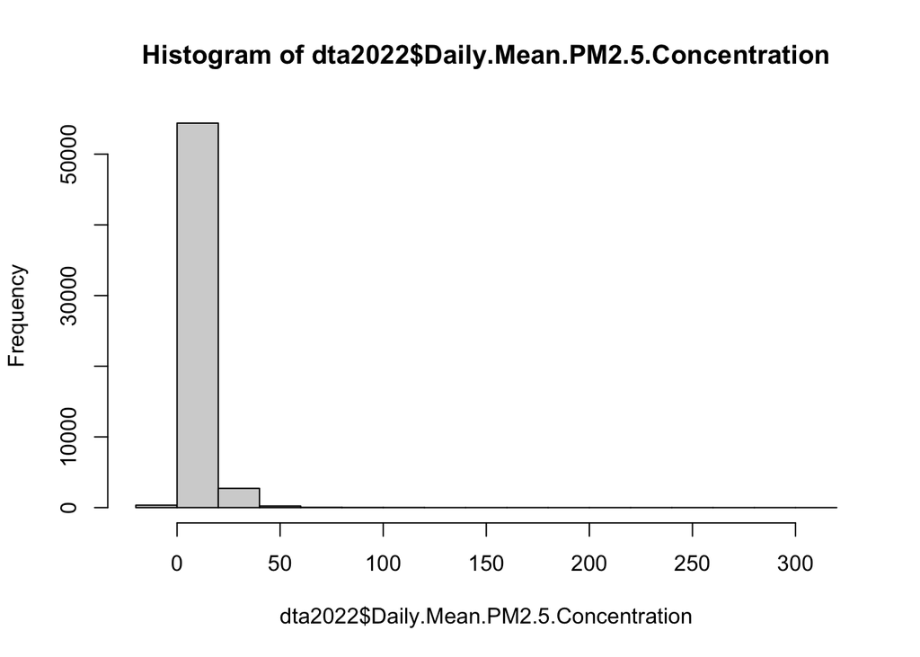

```r
hist(dta2022$Daily.Mean.PM2.5.Concentration)
```

```r
dta2022 <- dta2022[order(dta2022$Daily.Mean.PM2.5.Concentration),]
dta2002 <- dta2002[order(dta2002$Daily.Mean.PM2.5.Concentration),]

tail(dta2002$Daily.Mean.PM2.5.Concentration,50)
```

```
 [1]  80.0  80.3  80.4  80.7  80.7  80.9  81.0  81.1  81.3  81.6  82.0  82.0
[13]  82.0  82.1  83.0  83.0  83.1  83.9  84.0  84.0  84.1  84.2  84.2  84.4
[25]  84.6  85.0  85.3  85.6  85.6  85.7  86.0  86.2  86.6  87.0  87.0  87.4
[37]  87.5  88.0  88.6  89.3  89.6  89.8  90.7  91.0  91.0  91.7  92.5  93.9
[49] 102.7 104.3
```

```r
tail(dta2022$Daily.Mean.PM2.5.Concentration,50)
```

```
 [1]  83.9  84.4  84.5  85.2  88.6  89.2  89.8  90.7  91.4  91.9  92.4  96.6
[13]  96.6  97.1  98.2 101.4 102.3 103.0 105.0 106.4 107.2 108.0 108.8 109.5
[25] 110.2 111.1 111.6 113.6 113.7 118.7 122.0 131.7 133.8 141.1 141.8 150.9
[37] 155.2 168.7 169.0 177.1 178.6 181.7 212.8 228.3 237.5 243.9 244.7 246.2
[49] 296.3 302.5
```

```r
table(dta2002$Date)
```

```
01/01/2002 01/02/2002 01/03/2002 01/04/2002 01/05/2002 01/06/2002 01/07/2002
        18        102         18         19         83         19         19
01/08/2002 01/09/2002 01/10/2002 01/11/2002 01/12/2002 01/13/2002 01/14/2002
        99         21         19         73         20         16        104
01/15/2002 01/16/2002 01/17/2002 01/18/2002 01/19/2002 01/20/2002 01/21/2002
        20         19         83         18         17        108         18
01/22/2002 01/23/2002 01/24/2002 01/25/2002 01/26/2002 01/27/2002 01/28/2002
        17         75         17         18        115         18         18
01/29/2002 01/30/2002 01/31/2002 02/01/2002 02/02/2002 02/03/2002 02/04/2002
        76         21         13        112         17         16         77
02/05/2002 02/06/2002 02/07/2002 02/08/2002 02/09/2002 02/10/2002 02/11/2002
        21         22        120         21         20         83         16
02/12/2002 02/13/2002 02/14/2002 02/15/2002 02/16/2002 02/17/2002 02/18/2002
        20        111         20         23         84         21         21
02/19/2002 02/20/2002 02/21/2002 02/22/2002 02/23/2002 02/24/2002 02/25/2002
       112         16         20         85         21         21        114
02/26/2002 02/27/2002 02/28/2002 03/01/2002 03/02/2002 03/03/2002 03/04/2002
        19         21         83         23         20        113         20
03/05/2002 03/06/2002 03/07/2002 03/08/2002 03/09/2002 03/10/2002 03/11/2002
        17         82         19         20        124         23         21
03/12/2002 03/13/2002 03/14/2002 03/15/2002 03/16/2002 03/17/2002 03/18/2002
        86         22         21        119         24         20         80
03/19/2002 03/20/2002 03/21/2002 03/22/2002 03/23/2002 03/24/2002 03/25/2002
        22         21        117         22         20         83         20
03/26/2002 03/27/2002 03/28/2002 03/29/2002 03/30/2002 03/31/2002 04/01/2002
        20        115         18         22         88         21         16
04/02/2002 04/03/2002 04/04/2002 04/05/2002 04/06/2002 04/07/2002 04/08/2002
       114         15         16         67         16         17        117
04/09/2002 04/10/2002 04/11/2002 04/12/2002 04/13/2002 04/14/2002 04/15/2002
        15         20         73         15         12        119         16
04/16/2002 04/17/2002 04/18/2002 04/19/2002 04/20/2002 04/21/2002 04/22/2002
        18         68         12         14        124         15         14
04/23/2002 04/24/2002 04/25/2002 04/26/2002 04/27/2002 04/28/2002 04/29/2002
        75         16         14        122         17         15         73
04/30/2002 05/01/2002 05/02/2002 05/03/2002 05/04/2002 05/05/2002 05/06/2002
        17         15        115         12         16         71         13
05/07/2002 05/08/2002 05/09/2002 05/10/2002 05/11/2002 05/12/2002 05/13/2002
        15        119         14         13         76         16         15
05/14/2002 05/15/2002 05/16/2002 05/17/2002 05/18/2002 05/19/2002 05/20/2002
       123         16         16         69         15         15        119
```

[output cut: 51 more lines]

```
        18         81         18         21        116         19         18
11/19/2002 11/20/2002 11/21/2002 11/22/2002 11/23/2002 11/24/2002 11/25/2002
        85         22         23        115         22         20         73
11/26/2002 11/27/2002 11/28/2002 11/29/2002 11/30/2002 12/01/2002 12/02/2002
        20         19        115         24         26         82         19
12/03/2002 12/04/2002 12/05/2002 12/06/2002 12/07/2002 12/08/2002 12/09/2002
        21        117         20         23         82         18         16
12/10/2002 12/11/2002 12/12/2002 12/13/2002 12/14/2002 12/15/2002 12/16/2002
       114         21         18         81         17         16        104
12/17/2002 12/18/2002 12/19/2002 12/20/2002 12/21/2002 12/22/2002 12/23/2002
        18         19         80         17         19        110         17
12/24/2002 12/25/2002 12/26/2002 12/27/2002 12/28/2002 12/29/2002 12/30/2002
        23         88         21         18        119         23         21
12/31/2002
        91
```

```r
table(dta2022$Date)
```

```
01/01/2022 01/02/2022 01/03/2022 01/04/2022 01/05/2022 01/06/2022 01/07/2022
       147        180        144        146        198        139        140
01/08/2022 01/09/2022 01/10/2022 01/11/2022 01/12/2022 01/13/2022 01/14/2022
       178        142        142        204        143        143        180
01/15/2022 01/16/2022 01/17/2022 01/18/2022 01/19/2022 01/20/2022 01/21/2022
       147        146        208        144        148        182        147
01/22/2022 01/23/2022 01/24/2022 01/25/2022 01/26/2022 01/27/2022 01/28/2022
       147        203        147        147        181        146        142
01/29/2022 01/30/2022 01/31/2022 02/01/2022 02/02/2022 02/03/2022 02/04/2022
       205        148        145        181        149        152        202
02/05/2022 02/06/2022 02/07/2022 02/08/2022 02/09/2022 02/10/2022 02/11/2022
       150        150        182        146        145        203        148
02/12/2022 02/13/2022 02/14/2022 02/15/2022 02/16/2022 02/17/2022 02/18/2022
       149        184        147        149        205        150        149
02/19/2022 02/20/2022 02/21/2022 02/22/2022 02/23/2022 02/24/2022 02/25/2022
       185        149        148        213        149        152        187
02/26/2022 02/27/2022 02/28/2022 03/01/2022 03/02/2022 03/03/2022 03/04/2022
       151        151        207        146        148        180        146
03/05/2022 03/06/2022 03/07/2022 03/08/2022 03/09/2022 03/10/2022 03/11/2022
       145        209        147        148        184        148        143
03/12/2022 03/13/2022 03/14/2022 03/15/2022 03/16/2022 03/17/2022 03/18/2022
       198        142        140        180        146        148        207
03/19/2022 03/20/2022 03/21/2022 03/22/2022 03/23/2022 03/24/2022 03/25/2022
       148        148        181        145        145        194        140
03/26/2022 03/27/2022 03/28/2022 03/29/2022 03/30/2022 03/31/2022 04/01/2022
       140        177        140        143        198        143        143
04/02/2022 04/03/2022 04/04/2022 04/05/2022 04/06/2022 04/07/2022 04/08/2022
       182        147        147        199        147        148        182
04/09/2022 04/10/2022 04/11/2022 04/12/2022 04/13/2022 04/14/2022 04/15/2022
       149        149        205        148        145        176        145
04/16/2022 04/17/2022 04/18/2022 04/19/2022 04/20/2022 04/21/2022 04/22/2022
       147        204        146        142        180        143        140
04/23/2022 04/24/2022 04/25/2022 04/26/2022 04/27/2022 04/28/2022 04/29/2022
       204        142        143        176        142        140        198
04/30/2022 05/01/2022 05/02/2022 05/03/2022 05/04/2022 05/05/2022 05/06/2022
       142        141        177        143        145        205        142
05/07/2022 05/08/2022 05/09/2022 05/10/2022 05/11/2022 05/12/2022 05/13/2022
       141        176        141        140        195        141        141
05/14/2022 05/15/2022 05/16/2022 05/17/2022 05/18/2022 05/19/2022 05/20/2022
       181        145        141        207        145        143        178
```

[output cut: 51 more lines]

```
       147        206        147        146        174        146        147
11/19/2022 11/20/2022 11/21/2022 11/22/2022 11/23/2022 11/24/2022 11/25/2022
       202        147        144        179        143        144        196
11/26/2022 11/27/2022 11/28/2022 11/29/2022 11/30/2022 12/01/2022 12/02/2022
       142        146        174        145        147        196        142
12/03/2022 12/04/2022 12/05/2022 12/06/2022 12/07/2022 12/08/2022 12/09/2022
       144        175        139        141        203        145        141
12/10/2022 12/11/2022 12/12/2022 12/13/2022 12/14/2022 12/15/2022 12/16/2022
       179        144        145        200        146        143        171
12/17/2022 12/18/2022 12/19/2022 12/20/2022 12/21/2022 12/22/2022 12/23/2022
       141        141        198        142        141        178        143
12/24/2022 12/25/2022 12/26/2022 12/27/2022 12/28/2022 12/29/2022 12/30/2022
       144        194        146        140        170        141        139
12/31/2022
       189
```

```r
summary(dta2002$SITE_LATITUDE)
```

```
   Min. 1st Qu.  Median    Mean 3rd Qu.    Max.
  32.63   34.07   35.36   36.00   37.77   41.71
```

```r
summary(dta2002$SITE_LONGITUDE)
```

```
   Min. 1st Qu.  Median    Mean 3rd Qu.    Max.
 -124.2  -121.4  -119.1  -119.4  -117.9  -115.5
```

```r
summary(dta2022$SITE_LATITUDE)
```

```
   Min. 1st Qu.  Median    Mean 3rd Qu.    Max.
  32.58   34.14   36.60   36.37   38.10   41.76
```

```r
summary(dta2022$SITE_LONGITUDE)
```

```
   Min. 1st Qu.  Median    Mean 3rd Qu.    Max.
 -124.2  -121.5  -119.8  -119.7  -118.1  -115.5
```

From our initial exploratory analysis we see that Pm2.5 levels in 2002 range from 0 to 104.3 and in 2022 they range from -2.2 to 302.5. The mean Pm2.5 level in 2002 was 16.12 and in 2022 the mean was 8.56. All these values are legitimate Pm2.5 values. In addition, our date variable has no inordinary dates or patterns. These are the most important variables to look at in regard to answering our main question.

In regard to missingness, CBSA_CODE is the only variable with missing values in both datasets. Considering our analysis does not require this variable, there is no case to manipulate the variable. Neither the latitude or longitude variables had any points that seem to be extreme or improperly inputted.

## Question 2

```r
joined <- rbind(dta2002, dta2022)
library(lubridate)
joined$year <- year(mdy(joined$Date))
names(joined)[names(joined) == "SITE_LATITUDE"] <- "lat"
names(joined)[names(joined) == "SITE_LONGITUDE"] <- "lon"
names(joined)[names(joined) == "Daily.Mean.PM2.5.Concentration"] <- "pm25"
names(joined)
```

```
 [1] "Date"               "Source"             "Site.ID"
 [4] "POC"                "pm25"               "UNITS"
 [7] "DAILY_AQI_VALUE"    "Site.Name"          "DAILY_OBS_COUNT"
[10] "PERCENT_COMPLETE"   "AQS_PARAMETER_CODE" "AQS_PARAMETER_DESC"
[13] "CBSA_CODE"          "CBSA_NAME"          "STATE_CODE"
[16] "STATE"              "COUNTY_CODE"        "COUNTY"
[19] "lat"                "lon"                "year"
```

## Question 3

```r
library(leaflet)

leafletdta <- unique(joined, by="Site.ID")

yr.pal <- colorFactor(c('darkblue','lightgreen'), domain=joined$year)
yr.pal
```

[output not shown]

```r
epamap <- leaflet(leafletdta) %>%
  addProviderTiles('CartoDB.Positron') %>%
  addCircles(
    lat = ~lat, lng=~lon,
    label = ~paste0(round(year,2), ' C'), color = ~ yr.pal(year),
    opacity = 1, fillOpacity = 1, radius = 500
    ) %>%
  addLegend('bottomleft', pal=yr.pal, values=leafletdta$year,
          title='Year', opacity=1)

epamap
```

[interactive chart not shown]

In observing the spatial distribution of the sites, I notice many of the EPA sites are located along the coast of California or towards the middle of the state from a vertical standpoint. There is a large conglomeration of sites in both the Bay area (San Jose, San Francisco) and the Southern California area (Los Angeles, San Diego) as well. The mountainous region located on the eastern side of the state has fewer sites compared to the coastal area and other major cities. Additionally, I notice many of the sites changed in location from the year of 2002 to the year of 2022.

## Question 4

```r
joined <- joined[order(joined$pm25),]
attach(joined)
summary(pm25)
```

```
   Min. 1st Qu.  Median    Mean 3rd Qu.    Max.
   -2.2     4.5     7.7    10.2    12.4   302.5
```

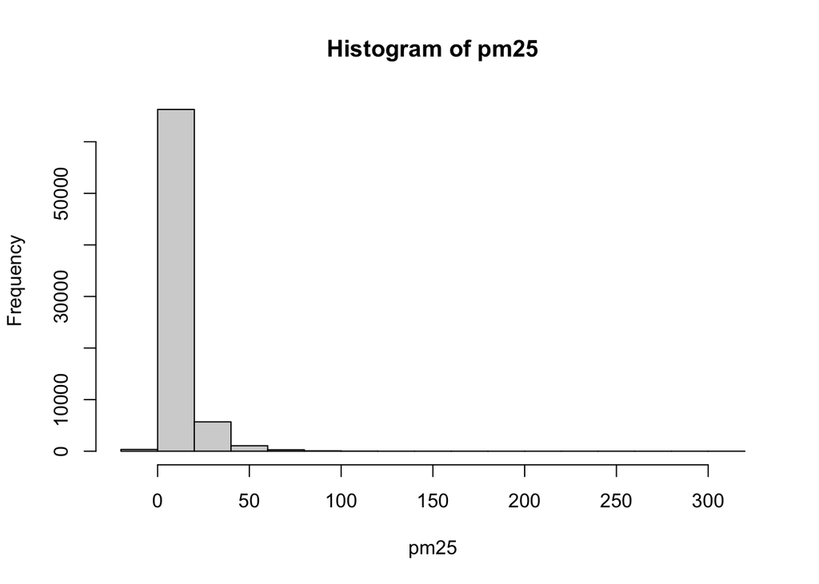

```r
hist(pm25)
```

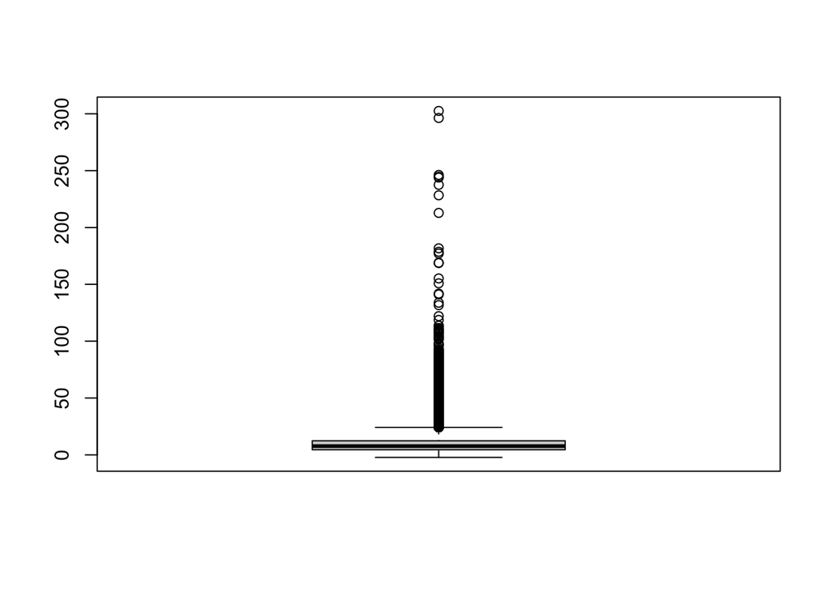

```r
boxplot(pm25)
```

```r
head(pm25,10) # obseve potential outliers at low end of range
```

```
 [1] -2.2 -2.0 -1.9 -1.9 -1.7 -1.5 -1.4 -1.4 -1.4 -1.4
```

```r
tail(pm25,10) # obseve potential outliers at high end of range
```

```
 [1] 178.6 181.7 212.8 228.3 237.5 243.9 244.7 246.2 296.3 302.5
```

```r
is.numeric(pm25) # make sure the data is all numeric
```

```
[1] TRUE
```

```r
length(which(is.na(pm25))) # check NAs
```

```
[1] 0
```

```r
tapply(pm25, year, summary) #rechecking distribution by year
```

```
$`2002`
   Min. 1st Qu.  Median    Mean 3rd Qu.    Max.
   0.00    7.00   12.00   16.12   20.50  104.30

$`2022`
   Min. 1st Qu.  Median    Mean 3rd Qu.    Max.
 -2.200   4.200   7.000   8.564  10.900 302.500
```

```r
pm25summary <- joined %>%
  group_by(year) %>%
  summarize(mean = mean(pm25),
            sum = sum(pm25),
            min = min(pm25),
            q1 = quantile(pm25, 0.25),
            median= median(pm25),
            q3 = quantile(pm25, 0.75),
            max = max(pm25),
            sd = sd(pm25),
            npm25 = n()
            )
pm25summary
```

```
# A tibble: 2 × 10
   year  mean     sum   min    q1 median    q3   max    sd npm25
  <dbl> <dbl>   <dbl> <dbl> <dbl>  <dbl> <dbl> <dbl> <dbl> <int>
1  2002 16.1  257468.   0     7       12  20.5  104. 13.9  15976
2  2022  8.56 494662.  -2.2   4.2      7  10.9  302.  7.77 57761
```

```r
# How many observations of pm2.5 in 2022 is greater than the greatest observation of pm2.5 in 2002
temp <- joined %>%
    group_by(year) %>%
    summarize(hmg = sum(pm25 > 104.3))
temp
```

```
# A tibble: 2 × 2
   year   hmg
  <dbl> <int>
1  2002     0
2  2022    32
```

None of the values appear to be missing. In addition, the range of the measurement (pm25) is -2.2 to 302.5. Upon further research it appears that the upper limit of the range is in fact a valid measure of pm25 and according to the EPA is indicative that the air quality is very hazardous. As far as the negative measurements go; if the atmosphere is very clean (approaching 0 μg/m3) and there is noise in the measurement, then a negative number may in fact be valid. By invalidating data or correcting to 0, it may potentially lead to biasing data higher. Therefore, I personally think it is of the best interest to keep all data points for the pm25 measurement in the data.

During the year of 2002, 15,976 observations were taken and during the year of 2022, 57,761 observations were taken. The summaries of the daily concentrations of PM2.5 grouped by year indicate that the mean daily PM2.5 measurement from 2002 to 2022 decreased by 7.56. As well, the standard deviation of the data between the years of 2002 and 2022 decreased significantly from 13.87 to 7.77. This most likely is explained by the increase in the number of observations used when comparing the year of 2002 to 2022. This being said the range in the year 2022 was much larger than the range of 2002 and there were 32 observations of PM2.5 from the year 2022 that were greater than the greatest observation of PM2.5 in 2002.

## Question 5

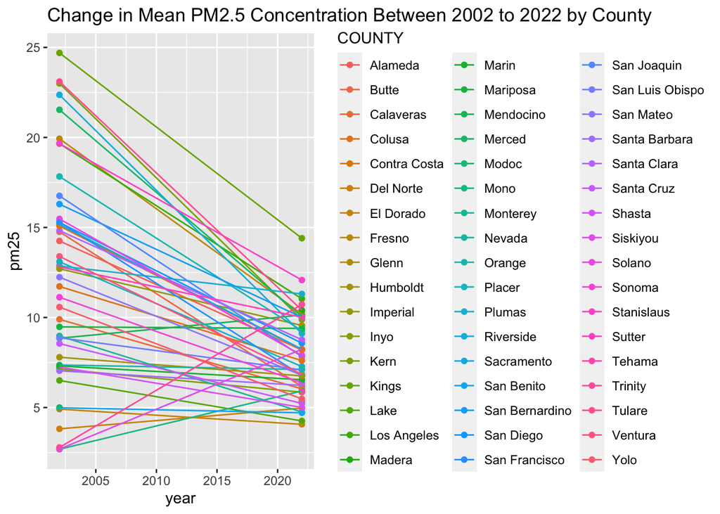

```r
#County-level
joined_avg <- joined[,.(
  pm25     = mean(pm25,na.rm=TRUE)
), by=c("COUNTY", "year")]

ggplot(data = joined_avg) +
  geom_point(mapping = aes(x = year, y = pm25, color = COUNTY)) +geom_line(mapping = aes(x = year, y = pm25, color = COUNTY)) + labs(title="Change in Mean PM2.5 Concentration Between 2002 to 2022 by County")
```

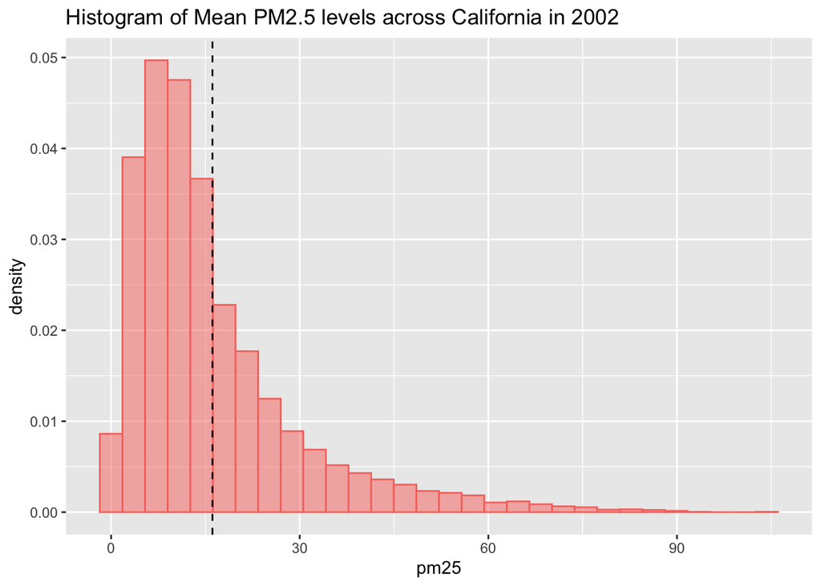

```r
#State-Level
library(stats)
joined2002 <- joined %>% filter(year==2002)
joined2022 <- joined %>% filter(year==2022)
pm25mean2022 = mean(joined2022$pm25)
pm25mean2002 = mean(joined2002$pm25)

ggplot(joined2002, aes(x=pm25, color=factor(year))) +
 geom_histogram(aes(y=..density.., colour="black", fill="orange"), alpha=0.5,
                position="identity")+labs(title="Histogram of Mean PM2.5 levels across California in 2002") +  theme(legend.position="none") + geom_vline(data=joined2002, aes(xintercept=pm25mean2002),
               linetype="dashed", size=0.5)
```

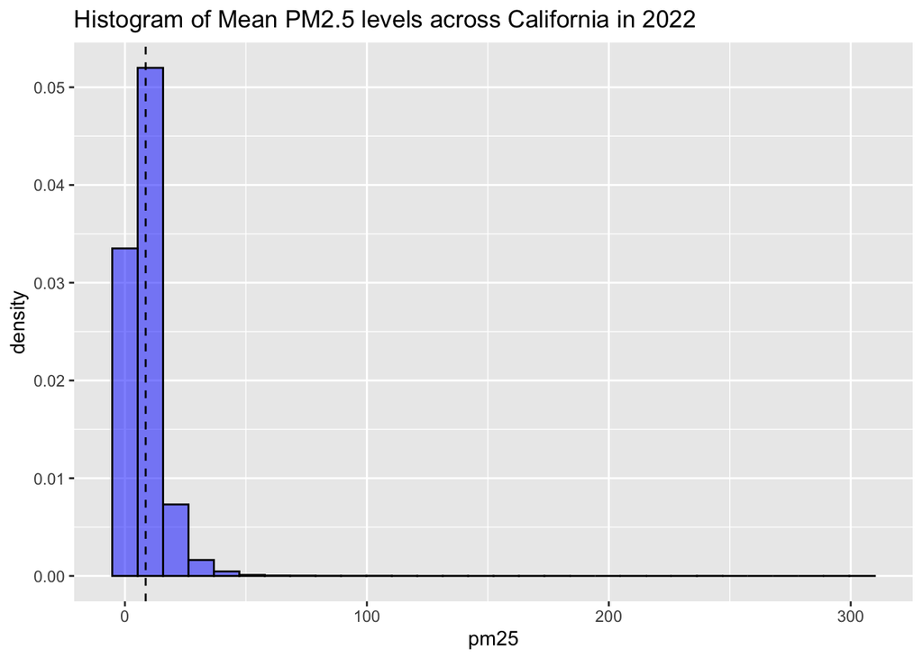

```r
ggplot(joined2022, aes(x=pm25, color=factor(year))) +
 geom_histogram(aes(y=..density..),colour="black", fill="blue", alpha=0.5,
                position="identity") + labs(title="Histogram of Mean PM2.5 levels across California in 2022") + geom_vline(data=joined2022, aes(xintercept=pm25mean2022),
               linetype="dashed", size=0.5)
```

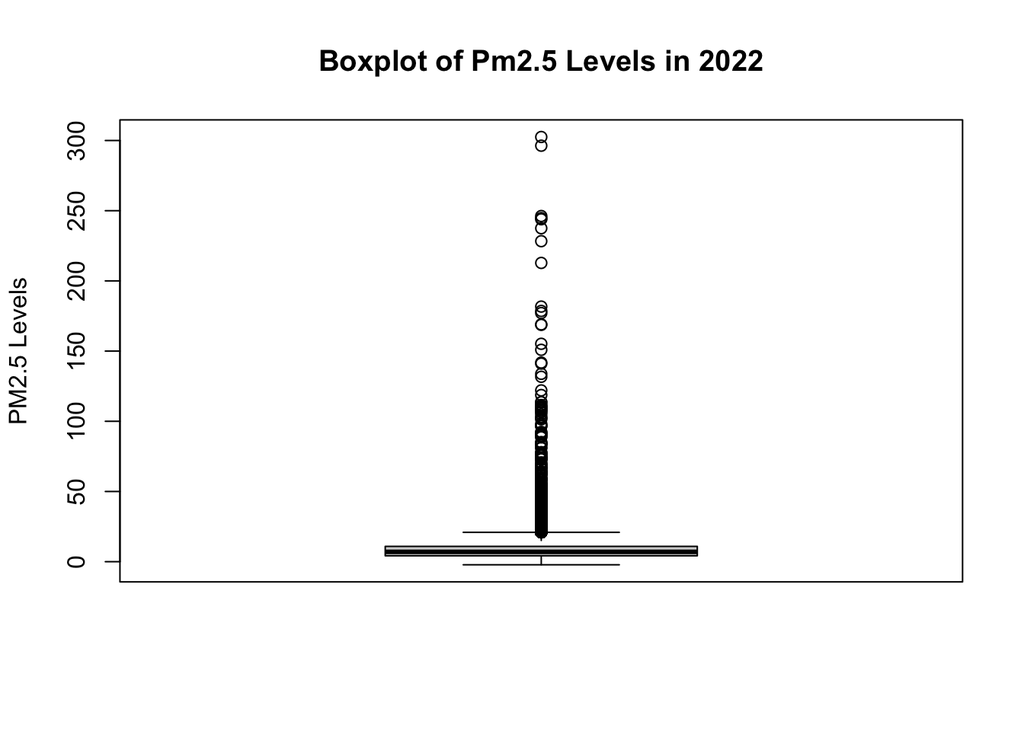

```r
boxplot(joined2022$pm25, main="Boxplot of Pm2.5 Levels in 2022",ylab="PM2.5 Levels")
```

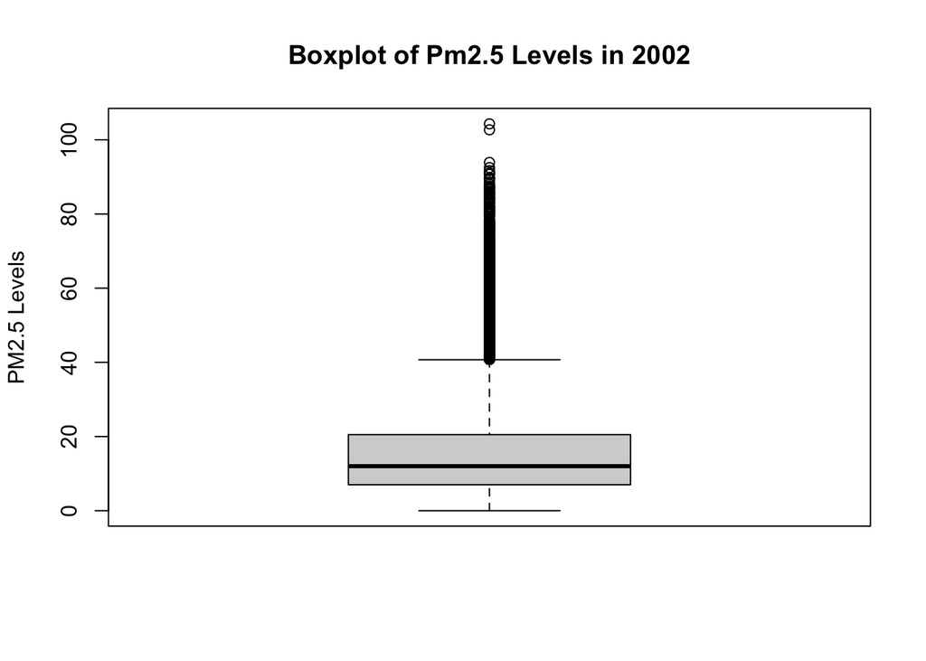

```r
boxplot(joined2002$pm25, main="Boxplot of Pm2.5 Levels in 2002",ylab="PM2.5 Levels")
```

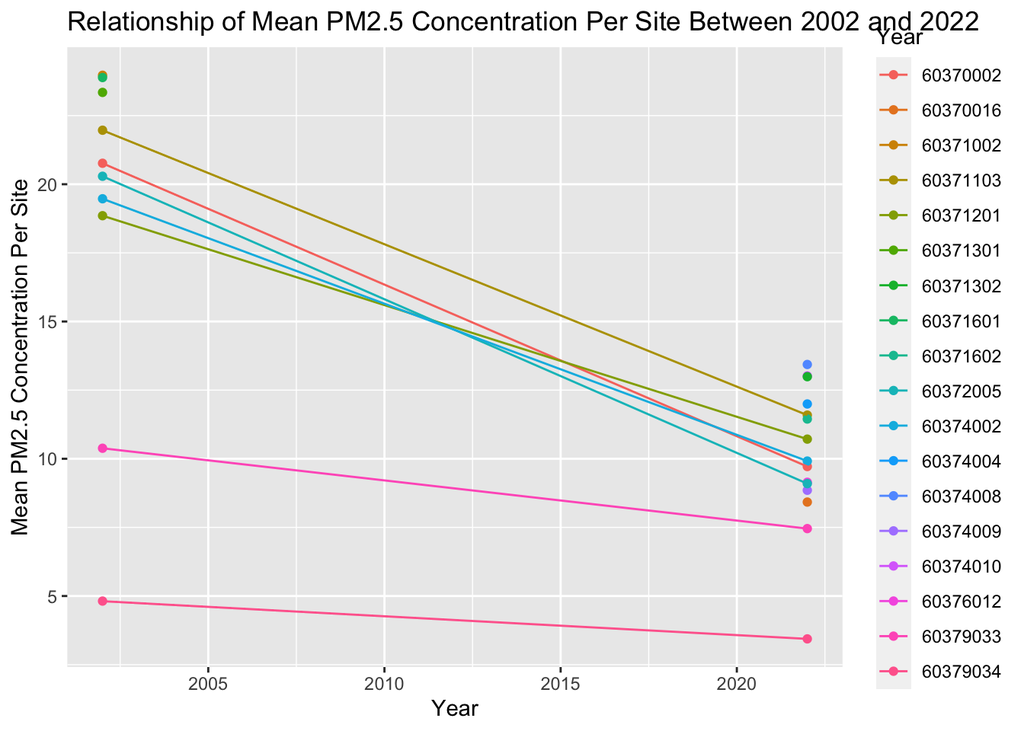

```r
#Site-Level
joined_avg2 <- joined[,.(
  pm25     = mean(pm25,na.rm=TRUE)
), by=c("Site.ID", "year","COUNTY")]
joined_avg2 <-joined_avg2 %>% filter(COUNTY=="Los Angeles")

ggplot(data = joined_avg2) +
  geom_point(mapping = aes(x = year, y = pm25, color = factor(Site.ID))) + geom_line(mapping = aes(x = year, y = pm25, color = as.factor(Site.ID)))+ xlab("Year") + ylab("Mean PM2.5 Concentration Per Site") + labs( title='Relationship of Mean PM2.5 Concentration Per Site Between 2002 and 2022') + labs(color = "Year")
```

After observing the plots provided for each level here is our interpretation of what we observe.

State-Level: At the state level, which includes all all the original data points, we see a distinct difference in both the histograms and the box plots for each respective year 2002 and 2022.

County-Level: At the county level we plot the mean values for each county for both years of 2002 and 2022. We notice that from the year 2002 to the year 2022 a large majority of the counties have a negative slope indicating the PM2.5 levels decreased between the two years.

Site-Level: Of the sites in Los Angeles county, of which we collected data in both 2002 and 2022, all of them exhibit a negative slope again indicating the PM2.5 levels decreased between the two years.

At each level (state, county, and site) we see a decrease in the particulate matter air pollution with aerodynamic diameter less than 2.5 levels. From this information we can infer that in general Pm2.5 levels have decreased in California over the last 20 years (from 2002 to 2022).